# `BayesBrainMap` step 2 demo: subject-level brain mapping

Nohelia Da Silva Sanchez, Diego Derman, Saige Rutherford, Damon D. Pham, Ellyn Butler, Mary Beth Nebel, Amanda F. Mejia

## Bayesian Brain Mapping Overview

This demo accompanies the manuscript “Bayesian brain mapping: population-informed individualized functional topography and connectivity” ([Da Silva Sanchez et al., 2026](https://arxiv.org/abs/2602.01551v1)), which provides a comprehensive introduction to Bayesian Brain Mapping (BBM). Briefly, there are two steps to performing BBM, both implemented in the `BayesBrainMap` R package: *(1) prior estimation* and *(2) model fitting*.

In this demo we will walk through the code for the second step. If you aim to calculated your own prior, or want to understand how prior estimation works, please revisit `demo_step1`, available in the same repository.

The code shown within this demo is intended for learning purposes, and is not intended to be run within this demo due to computational resources and data availability (we cannot share the HCP data ourselves). However, we do provide instructions for running all steps yourself and the goal is to teach you how to do so.

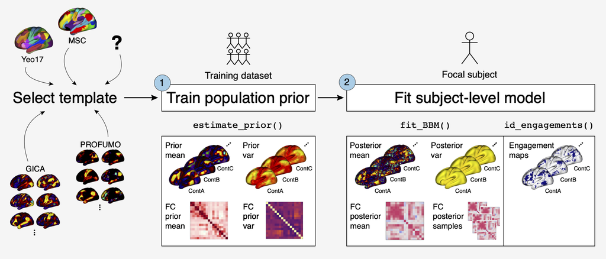

Figure 1: Overview of Bayesian Brain Mapping. The two main steps are (1) prior estimation and (2) model fitting.

## Setup

To reproduce this workflow, first clone the repository to your local machine or cluster:

```bash
git clone https://github.com/mandymejia/BBM-priors.git # if you are running this file, you have already done this step
cd BBM-priors/
```

This GitHub repository contains the priors for the Yeo17 parcellation. If you wish to use another parcellation (i.e., GICA, MSC, PROFUMO) they can be downloaded from [OSF](https://osf.io/k6vx8/files/osfstorage). Once you have downloaded additional priors from OSF, they should be moved into the `priors/` folder within the data `folder/` to match the structure shown below.

The folder structure should look like this, including a `data/templates` directory containing hard parcellations, continuous networks maps, to be used as templates for estiamting priors. The `data/posteriors` directory will contain the subject-level brain maps estimated in the model fitting step, and the `data/priors` directory will contain the population-level priors estimated in the prior estimation step (see Figure).

```
BBM-priors/
├── data/
│   ├── templates/
│   ├── posteriors/
│   └── priors/
│       └────  Yeo17/
│       └────  ...
├── src/
│   ├── 00_main.R
│   ├── 0_setup.R
│   ├── 1_fd_time_filtering.R
│   └── ...
├── demo/
│   └── BBM-demo.Rmd
└── ...
```

This section initializes the environment by loading required packages, setting analysis parameters, and defining directory paths.

**Important:** Before running the workflow, you must review `0_setup.R` and install any necessary packages, ensure you have an installation of Connectome Workbench, and update the following variables to match your local or cluster environment:

- `dir_project` (path to the GitHub folder)
- `dir_train` (path to the HCP data)
- `HCP_unrestricted_fname` (path to the unrestricted HCP CSV if you have access to it)
- `HCP_restricted_fname` (path to the restricted HCP CSV if you have access to it)
- `wb_path` (location of the CIFTI Workbench on your system)

```r
github_repo_dir <- getwd()
src_dir <- file.path(github_repo_dir, "../src")
source(file.path(src_dir, "0_setup.R"))
```

## Using Priors for Individual-Level Brain Mapping

In this section, we demonstrate how to apply the population-level priors to perform subject-level analysis using the `BayesBrainMap` package.

The process involves two steps:

1. Fitting the Bayesian brain mapping model to subject data using a precomputed prior.
2. Identifying regions of significant deviation from the prior mean (i.e., areas of engagement).

### Load Subject-Level fMRI Data and Prior

```r
# Load population prior
prior <- readRDS(file.path(dir_data, "priors/Yeo17/prior_combined_Yeo17_noGSR.rds"))
hcp_subject <- "101006"
session <- "rfMRI_REST1_LR"
dir_train <- "/LOCAL/HCP_DIR" # replace with your local HCP directory
# Load subject fMRI data (CIFTI format)
BOLD_1 <- c(file.path(dir_train, hcp_subject, "MINonLinear/Results", session,
                    paste0(session, "_Atlas_MSMAll_hp2000_clean.dtseries.nii")))
```

The fMRI input must be a CIFTI, NIFTI, or matrix object compatible with the prior.

### Estimate Subject-Level Networks

**The code below is shown for reference only** — it requires HCP data and is computationally intensive. A pre-computed result is included in the repository and loaded in the block that follows.

```r
bMap_1 <- fit_BBM(
  BOLD = BOLD_1,
  prior = prior,
  TR = 0.72,
  drop_first = 15,
  GSR = FALSE
  )
```

Or load the pre-computed brain map included in the *data_OSF* repository:

```r
# download the prior from OSF and place it in data/priors/Yeo17/ before running this code
osf_url <- "https://osf.io/k6vx8/files/qswaz"
posterior_download <- osf_download(osf_retrieve_file(osf_url), path = file.path(dir_data, "posteriors", "sub-103111", "Yeo17"))

bMap_1 <- readRDS(file.path(dir_data, "posteriors", "sub-103111", "Yeo17", "sub-103111_BBM.rds"))
```

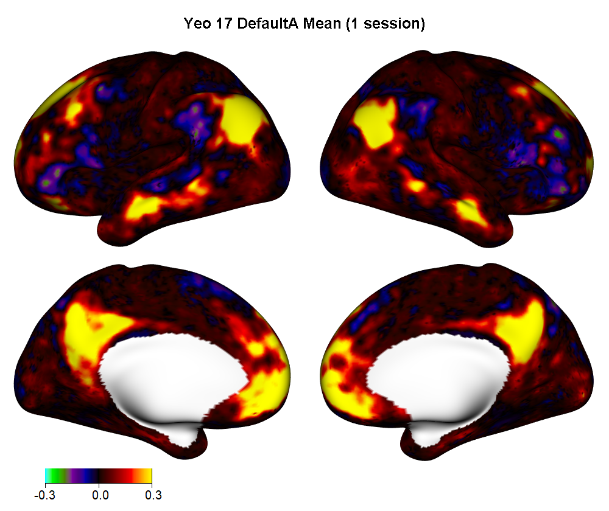

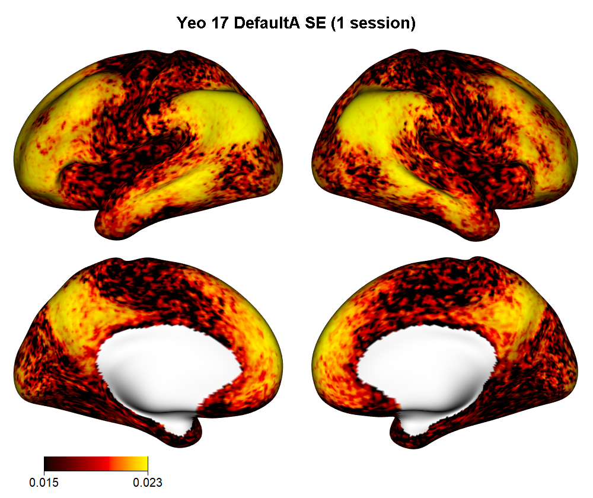

### Identify Engagement Maps

**The code below is shown for reference only.** A pre-computed engagement map is included in the repository and loaded further below.

```r
eng <- engagements(
  bMap = bMap_1,
  method_p = 'bonferroni',
  z=5
  )
```

Or load the pre-computed engagement map included in the repository:

```r
eng <- readRDS(file.path(dir_data, "posteriors", "sub-103111", "Yeo17", "engagements_1session.rds"))
```

**The code below is shown for reference only.** A pre-computed result is included in the repository and loaded further below.

```r
eng_multipleZ <- engagements(
  bMap = bMap_1,
  method_p = 'bonferroni',
  z = c(1,5)
  )
```

Or load the pre-computed multiple-z engagement maps included in the repository:

```r
eng_multipleZ <- readRDS(file.path(dir_data, "posteriors", "sub-103111", "Yeo17", "engagements_1session_multipleZ.rds"))
```

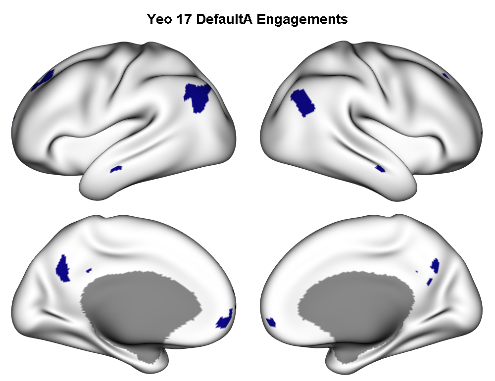

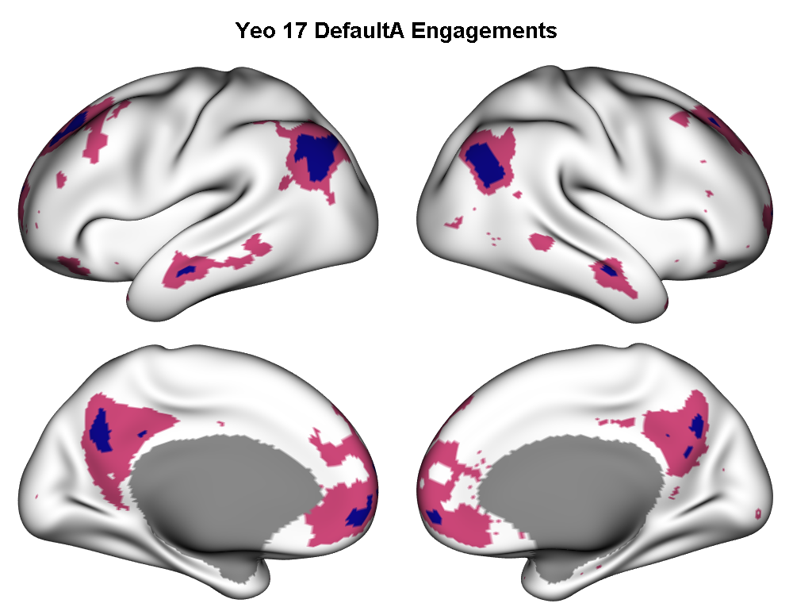